# Linear Model Selection and Regularization (ISL 6)

### 5.2 Lasso

- Ridge regression does have one obvious disadvantage: unlike subset selections, which will generally select models that involve just a subset of the variables, ridge regression will include all $p$ predictors in the final model.
- **Lasso** is a relatively recent alternative to ridge regression that overcomes this disadvantage. The lasso coefficients, $\hat{\beta}_\lambda^L$, minimize the quantity
  $$\text{RSS} + \lambda \sum_{j=1}^p |\beta_j|.$$
- In statistical parlance, the lasso uses an $\ell_1$ (pronounced “ell 1”) penalty instead of an $\ell_2$ penalty. The $\ell_1$ norm of a coefficient vector $\beta$ is given by $\|\beta\|_1 = \sum_j |\beta_j|$.
- As with ridge regression, the lasso shrinks the coefficient estimates towards zero.
- However, in the case of the lasso, the $\ell_1$ penalty has the effect of forcing some of the coefficient estimates to be exactly equal to zero when the tuning parameter $\lambda$ is sufficiently large.
- Hence, much like best subset selection, the lasso performs **variable selection**.
- We say that the lasso yields **sparse** models. The models involve only a subset of the variables.
- As in ridge regression, selecting a good value of $\lambda$ for the lasso is critical. Cross-validation is again the method of choice.

**R**

Set up lasso model.

```r
lambda_grid <- c(0, 10^seq(-3, 4, length.out = 100))
lasso_mod <-
  # mixture = 0 (ridge), mixture = 1 (lasso)
  linear_reg(penalty = 1, mixture = 1) %>%
  set_engine("glmnet", path_values = lambda_grid)
lasso_mod
```

```
Linear Regression Model Specification (regression)

Main Arguments:
  penalty = 1
  mixture = 1

Engine-Specific Arguments:
  path_values = lambda_grid

Computational engine: glmnet
```

Bundle recipe and model into a workfolow.

```r
lasso_wf <- workflow() %>%
  add_model(lasso_mod) %>%
  add_recipe(norm_recipe)
lasso_wf
```

```
══ Workflow ════════════════════════════════════════════════════════════════════
Preprocessor: Recipe
Model: linear_reg()

── Preprocessor ────────────────────────────────────────────────────────────────
3 Recipe Steps

• step_dummy()
• step_zv()
• step_normalize()

── Model ───────────────────────────────────────────────────────────────────────
Linear Regression Model Specification (regression)

Main Arguments:
  penalty = 1
  mixture = 1

Engine-Specific Arguments:
  path_values = lambda_grid

Computational engine: glmnet
```

```r
fit_lasso <- lasso_wf %>% fit(data = Credit)
```

```
# A tibble: 781 × 5
   term         step estimate lambda dev.ratio
   <chr>       <dbl>    <dbl>  <dbl>     <dbl>
 1 (Intercept)     1     520. 10000          0
 2 (Intercept)     2     520.  8498.         0
 3 (Intercept)     3     520.  7221.         0
 4 (Intercept)     4     520.  6136.         0
 5 (Intercept)     5     520.  5214.         0
 6 (Intercept)     6     520.  4431.         0
 7 (Intercept)     7     520.  3765.         0
 8 (Intercept)     8     520.  3199.         0
 9 (Intercept)     9     520.  2719.         0
10 (Intercept)    10     520.  2310.         0
# ℹ 771 more rows
```

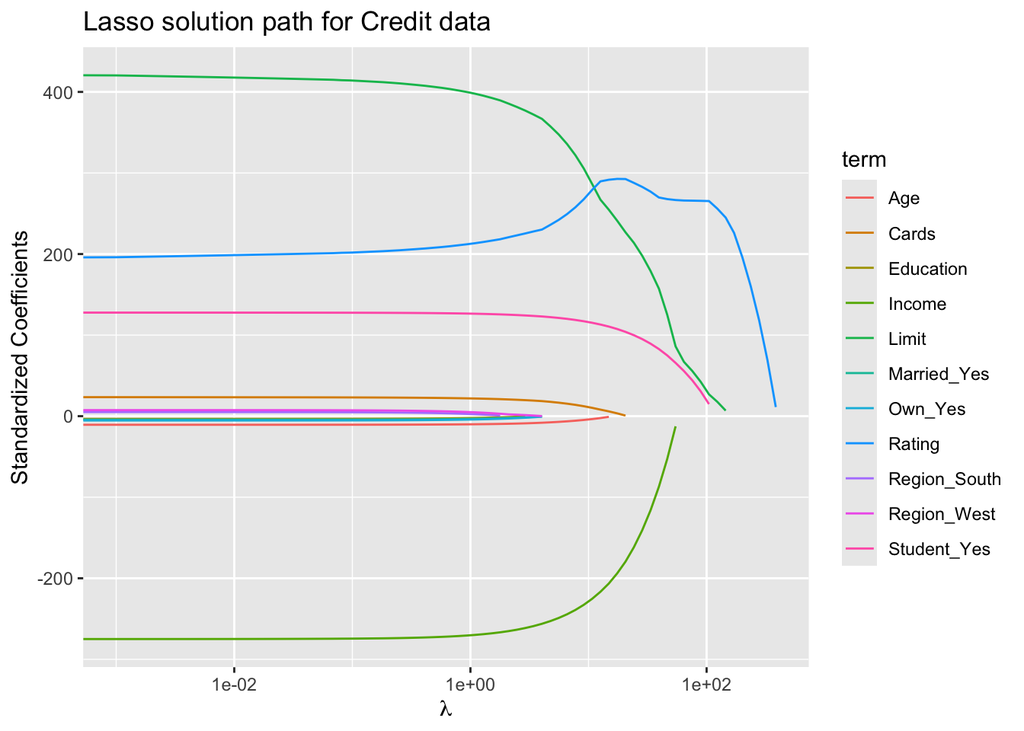

```r
broom:::tidy.glmnet(fit_lasso$fit$fit$fit) %>%
  print(width = Inf) %>%
  filter(term != "(Intercept)") %>%
  ggplot() +
  geom_line(mapping = aes(x = lambda, y = estimate, color = term)) +
  scale_x_log10() +
  labs(
    x = quote(lambda),
    y = "Standardized Coefficients",
    title = "Lasso solution path for Credit data")
```

**Python**

```python
from sklearn.linear_model import Lasso

clf = Lasso()
# Ridge regularization parameter
alphas = np.logspace(start = -3, stop = 4, base = 10)
# Train the model with different regularization strengths
coefs = []
for a in alphas:
  clf.set_params(alpha = a)
  clf.fit(X, y)
  coefs.append(clf.coef_)
```

```
Lasso(alpha=np.float64(10000.0))
```

```python
# Visualize Ridge solution path
plt.figure(figsize = (10, 8))
ax = plt.gca()
ax.plot(alphas, coefs)
ax.set_xscale("log")
ax.legend(
  labels = ["_", "Student", "_", "_", "_", "Income", "Limit", "Rating", "_", "_", "_"],
  fontsize = 16
  )
plt.xlabel(r"$\alpha$")
plt.ylabel("Coefficients")
plt.title("Lasso solution path of Credit data")
plt.axis("tight")
```

```
(np.float64(0.00044668359215096305), np.float64(22387.21138568338), np.float64(-310.91938191371315), np.float64(486.5300590239807))
```

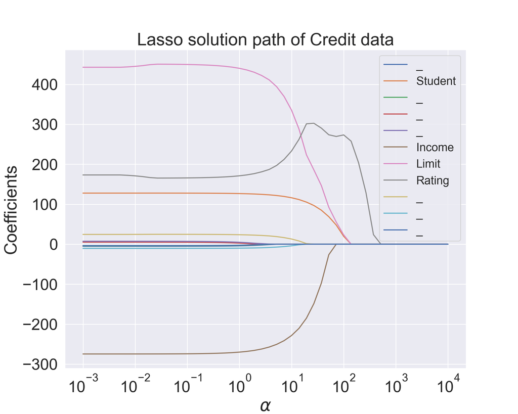

```python
plt.show()
```

[figure not shown]

Figure 5: Lasso solution path for the `Credit` data (ISL Figure 6.6).

- Why is it that the lasso, unlike ridge regression, results in coefficient estimates that are exactly equal to zero?

  One can show that the lasso and ridge regression coefficient estimates solve the problems
  $$\text{minimize } \text{RSS} \quad \text{ subject to } \sum_{j=1}^p |\beta_j| \le s$$
  and
  $$\text{minimize } \text{RSS} \quad \text{ subject to } \sum_{j=1}^p \beta_j^2 \le s$$
  respectively.

[figure not shown]

Figure 6: Contours of the RSS and constraint functions for the lasso (left) and ridge regression (right). The solid blue areas are the constraint regions, $|\beta_1| + |\beta_2| \le s$ and $\beta_1^2 + \beta_2^2 \le s$, while the red ellipses are the contours of the RSS.

### 5.3 Comparing ridge and lasso

- Simulation example with $n=50$ and $p=45$. All 45 predictors are related to response.

[figure not shown]

Figure 7: Left: Plots of squared bias (black), variance (green), and test MSE (purple) for the lasso. Right: Comparison of squared bias, variance and test MSE between lasso (solid) and ridge (dashed). Both are plotted against their $R^2$ on the training data, as a common form of indexing. The crosses in both plots indicate the lasso model for which the MSE is smallest.

- Simulation example with $n=50$ and $p=45$. Only 2 predictors are related to response.

[figure not shown]

Figure 8: Left: Plots of squared bias (black), variance (green), and test MSE (purple) for the lasso. The simulated data is similar, except that now only two predictors are related to the response. Right: Comparison of squared bias, variance and test MSE between lasso (solid) and ridge (dashed). Both are plotted against their $R^2$ on the training data, as a common form of indexing. The crosses in both plots indicate the lasso model for which the MSE is smallest.

- These two examples illustrate that neither ridge regression nor the lasso will universally dominate the other.
- In general, one might expect the lasso to perform better when the response is a function of only a relatively small number of predictors.
- However, the number of predictors that is related to the response is never known *a priori* for real data sets.
- A technique such as **cross-validation** can be used in order to determine which approach is better on a particular data set.

### 5.4 Selecting the tuning parameter for ridge regression and lasso

- Similar to subset selection, for ridge regression and lasso we require a method to determine which of the models under consideration is best.
- That is, we require a method selecting a value for the tuning parameter $\lambda$ or equivalently, the value of the constraint $s$.
- **Cross-validation** provides a simple way to tackle this problem. We choose a grid of $\lambda$ values, and compute the cross-validation error rate for each value of $\lambda$.
- We then select the tuning parameter value for which the cross-validation error is smallest.
- Finally, the model is re-fit using all of the available observations and the selected value of the tuning parameter.

[figure not shown]

Figure 9: Left: Cross-validation errors that result from applying ridge regression to the `Credit` data set with various values of $\lambda$. Right: The coefficient estimates as a function of $\lambda$. The vertical dashed lines indicate the value of $\lambda$ selected by cross-validation. (ISL Figure 6.12)

## 6 Dimension reduction methods

- The methods that we have discussed so far have involved fitting linear regression models, via least squares or a shrunken approach, **using the original predictors**, $X_1, X_2, \ldots, X_p$.
- We now explore a class of approaches that transform the predictors and then fit a least squares model using the **transformed variables**. We will refer to these techniques as **dimension reduction** methods.
- Let $Z_1, Z_2, \ldots, Z_M$ represent $M < p$ **linear combinations** of our original $p$ predictors. That is
  $$Z_m = \sum_{j=1}^p \phi_{mj} X_j
  \tag{1}$$
  for some constants $\phi_{m1}, \ldots, \phi_{mp}$.
- We can then fit the linear regression model,
  $$y_i = \theta_0 + \sum_{m=1}^M \theta_m z_{im} + \epsilon_i, \quad i = 1,\ldots,n,
  \tag{2}$$
  using ordinary least squares. Here $\theta_0, \theta_1, \ldots, \theta_M$ are the regression coefficients.
- Notice that
  $$\sum_{m=1}^M \theta_m z_{im} = \sum_{m=1}^M \theta_m \sum_{j=1}^p \phi_{mj} x_{ij} = \sum_{j=1}^p \sum_{m=1}^m \theta_m \phi_{mj} x_{ij} = \sum_{j=1}^p \beta_j x_{ij},$$
  where
  $$\beta_j = \sum_{m=1}^m \theta_m \phi_{mj}.
  \tag{3}$$
- Hence model Equation 2 can be thought of as a special case of the original linear regression model.
- Dimension reduction serves to constrain the estimated $\beta_j$ coefficients, since now they must take the form Equation 3.
- Can win in the bias-variance tradeoff.

### 6.1 Principal components regression

- **Principal components regression (PCR)** applies principal components analysis (PCA) to define the linear combinations of the predictors, for use in our regression.
- The first principal component $Z_1$ is the (normalized) linear combination of the variables with the largest variance.
- The second principal component $Z_2$ has largest variance, subject to being uncorrelated with the first.
- And so on.
- Hence with many correlated original variables, we replace them with a small set of principal components that capture their joint variation.

[figure not shown]

Figure 10: The population size (`pop`) and ad spending (`ad`) for 100 different cities are shown as purple circles. The green solid line indicates the first principal component, and the blue dashed line indicates the second principal component.

- The first principal component
  $$Z_1 = 0.839 \times (\text{pop} - \bar{\text{pop}}) + 0.544 \times (\text{ad} - \bar{\text{ad}}).$$
  - Out of all possible linear combination of `pop` and `ad` such that $\phi_{11}^2 + \phi_{21}^2 = 1$ (why do we need this constraint?), this particular combination yields the highest variance.
  - There is also another interpretation for PCA: the first principal component vector defines the line that is as close as possible to the data.

[figure not shown]

Figure 11: A subset of the advertising data. Left: The first principal component, chosen to minimize the sum of the squared perpendicular distances to each point, is shown in green. These distances are represented using the black dashed line segments. Right: The left-hand panel has been rotated so that the first principal component lies on the $x$-axis.

- The first principal component appears to capture most of the information contained in the `pop` and `ad` predictors.

[figure not shown]

Figure 12: Plots of the first principal component scores $z_{i1}$ versus `pop` and `ad`. The relationships are strong.

- The second principal component
  $$Z_2 = 0.544 \times (\text{pop} - \bar{\text{pop}}) - 0.839 \times (\text{ad} - \bar{\text{ad}}).$$

[figure not shown]

Figure 13: Plots of the second principal component scores $z_{i2}$ versus `pop` and `ad`. The relationships are weak.

- PCR applied to two simulation data sets with $n=50$ and $p=45$:

[figure not shown]

Figure 14: PCR was applied to two simulated data sets. The black, green, and purple lines correspond to squared bias, variance, and test mean squared error, respectively. Left: all 45 predictors are related to response. Right: Only 2 out of 45 predictors are related to response.

- PCR applied to a data set where the first 5 principal components are related to response.

[figure not shown]

Figure 15: PCR, ridge regression, and the lasso were applied to a simulated data set in which the first five principal components of $X$ contain all the information about the response $Y$. In each panel, the irreducible error $\operatorname{Var}(\epsilon)$ is shown as a horizontal dashed line. Left: Results for PCR. Right: Results for lasso (solid) and ridge regression (dotted). The $x$-axis displays the shrinkage factor of the coefficient estimates, defined as the $\ell_2$ norm of the shrunken coefficient estimates divided by the $\ell_2$ norm of the least squares estimate.

- PCR applied to the `Credit` data:

[figure not shown]

Figure 16: PCR was applied to the `Credit` data.

- Note:
  - Even though PCR provides a simple way to perform regression using $M < p$ predictors, it is not a feature selection method.
  - When performing PCR, we generally recommend standardizing each predictor (below), prior to generating the principal components.
    $$\tilde{x}_{ij} = \frac{x_{ij}}{\sqrt{\frac{1}{n} \sum_{i=1}^n (x_{ij} - \bar{x}_j)^2}}.$$

### 6.2 Partial least squares (PLS)

- PCR identifies linear combinations, or **directions**, that best represent the predictors $X_1, \ldots, X_p$.
- These directions are identified in an **unsupervised way**, since the response $Y$ is not used to help determine the principal component directions.
- That is, the response does not **supervise** the identification of the principal components.
- Consequently, PCR suffers from a potentially serious drawback: there is no guarantee that the directions that best explain the predictors will also be the best directions to use for predicting the response.
- Like PCR, partial least squares (PLS) is a dimension reduction method, which first identifies a new set of features $Z_1, \ldots, Z_M$ that are linear combinations of the original features, and then fits a linear model via OLS using these $M$ new features.
- But unlike PCR, PLS identifies these new features in a supervised way. That is it makes use of the response $Y$ in order to identify new features that not only approximate the old features well, but also that **are related to the response**.
- Roughly speaking, the PLS approach attempts to find directions that help explain both the response and the predictors.
- PLS algorithm:
  - After standardizing the $p$ predictors, PLS computes the first direction $Z_1$ by setting each $\phi_{1j}$ in Equation 1 equal to the coefficient from the simple linear regression of $Y$ onto $X_j$.
  - One can show that this coefficient is proportional to the correlation between $Y$ and $X_j$.
  - Hence, in computing $Z_1 = \sum_{j=1}^p \phi_{1j} X_j$, PLS places the highest weight on the variables that are most strongly related to the response.
  - Subsequent directions are found by taking residuals and then repeating the above procedure.

## 7 Considerations in High Dimensions

- By dimension here we are referring to the size of $p$.
- Data sets containing more features $p$ than observations $n$ are often referred to as high-dimensional, i.e., $n<p$.
- Regression in High Dimensions
  - In high dimensions, the least squares estimates are highly variable, and exhibit high variance.

[figure not shown]

Figure 17: The lasso was performed with $n = 100$ observations and three values of $p$, the number of features. Of the $p$ features, $20$ were associated with the response. The boxplots show the test MSEs that result using three different values of the tuning parameter $\lambda$. For ease of interpretation, rather than reporting $\lambda$, the degrees of freedom are reported; for the lasso this turns out to be simply the number of estimated non-zero coefficients. When $p = 20$, the lowest test MSE was obtained with the smallest amount of regularization. When $p = 50$, the lowest test MSE was achieved when there is a substantial amount of regularization. When $p = 2,000$ the lasso performed poorly regardless of the amount of regularization, due to the fact that only 20 of the 2,000 features truly are associated with the outcome.

- Three important points:
  - regularization or shrinkage plays a key role in high-dimensional problems;
  - appropriate tuning parameter selection is crucial for good predictive performance, and
  - the test error tends to increase as the dimensionality of the problem (i.e. the number of features or predictors) increases, unless the additional features are truly associated with the response - “curse of dimensionality”
- In general, adding additional signal features that are truly associated with the response will improve the fitted model, i.e., a reduction in test set error.
- However, adding noise features that are not truly associated with the response will lead to a deterioration in the fitted model, and consequently an increased test set error.
  - In linear regression, the expected difference between the train and the test error is
    $$\mathbb{E}[\text{MSE}_{\text{test}} - \text{MSE}_{\text{train}}] = 2 \sigma^2 \frac{p}{n},$$
    where $\sigma^2$ is the variance of the error term $\epsilon$ in the linear regression model. Hence, as $p$ increases, the expected test error increases relative to the training error.

## 8 Summary

- Model selection methods are an essential tool for data analysis, especially for big datasets involving many predictors.
- Research into methods that give **sparsity**, such as the lasso is an especially hot area.
- Later, we will return to sparsity in more detail, and will describe related approaches such as the **elastic net**.

## 9 Lab